# Team

Karthikcharan Suresh

10/3/2019

The General Social Survey (GSS) has been run by NORC every other year since 1972 to keep track of current opinions across the United States. We are working with an excerpt of the dataset that covers years 1972 to 2016. The variable names along with a brief description are as follows:

[output not shown]

Now it’s important to understand what each column stands for. You can find a codebook with explanations for each of the variables at https://gssdataexplorer.norc.org/

## Data Cleaning

```r
hap <- readRDS("HAPPY.rds")
```

```r
names(hap) = tolower(names(hap))
```

Initial exploration revealed that some data processing was needed before we could proceed with further visualization. All missing values were encoded with ‘NA’ as follows:

```r
library(dplyr)
happydf<-data.frame(hap)
happydf<-na_if(happydf,"IAP")
happydf<-na_if(happydf,"DK")
happydf<-na_if(happydf,"NA")
head(happydf)
```

```
##           happy year age    sex       marital         degree       finrela
## 1 NOT TOO HAPPY 1972  23 FEMALE NEVER MARRIED       BACHELOR       AVERAGE
## 2 NOT TOO HAPPY 1972  70   MALE       MARRIED LT HIGH SCHOOL ABOVE AVERAGE
## 3  PRETTY HAPPY 1972  48 FEMALE       MARRIED    HIGH SCHOOL       AVERAGE
## 4 NOT TOO HAPPY 1972  27 FEMALE       MARRIED       BACHELOR       AVERAGE
## 5  PRETTY HAPPY 1972  61 FEMALE       MARRIED    HIGH SCHOOL ABOVE AVERAGE
## 6  PRETTY HAPPY 1972  26   MALE NEVER MARRIED    HIGH SCHOOL ABOVE AVERAGE
##      health wtssall          partyid polviews
## 1      GOOD  0.4446     IND,NEAR DEM     <NA>
## 2      FAIR  0.8893 NOT STR DEMOCRAT     <NA>
## 3 EXCELLENT  0.8893      INDEPENDENT     <NA>
## 4      GOOD  0.8893 NOT STR DEMOCRAT     <NA>
## 5      GOOD  0.8893  STRONG DEMOCRAT     <NA>
## 6      GOOD  0.4446     IND,NEAR DEM     <NA>
```

```r
sum(is.na(happydf))
```

```
## [1] 36391
```

In total there were 36391 number of missing values for the following 11 variables.

2. Variables were also cast into the correct type in order to ease data visualization. This was done by:

```r
sapply(happydf,class)
```

```
##       happy        year         age         sex     marital      degree
## "character"   "integer" "character" "character" "character" "character"
##     finrela      health     wtssall     partyid    polviews
## "character" "character"   "numeric" "character" "character"
```

```r
cols<-c("happy","sex","marital","degree","finrela","health","partyid","polviews")
happydf[cols]<-lapply(happydf[cols], factor)
sapply(happydf,class)
```

```
##       happy        year         age         sex     marital      degree
##    "factor"   "integer" "character"    "factor"    "factor"    "factor"
##     finrela      health     wtssall     partyid    polviews
##    "factor"    "factor"   "numeric"    "factor"    "factor"
```

```r
happydf$age[happydf$age=="89 OR OLDER"]<-89
happydf$age=as.numeric(happydf$age)
sapply(happydf,class)
```

```
##     happy      year       age       sex   marital    degree   finrela
##  "factor" "integer" "numeric"  "factor"  "factor"  "factor"  "factor"
##    health   wtssall   partyid  polviews
##  "factor" "numeric"  "factor"  "factor"
```

```r
happydf<-arrange(happydf,year,age,sex,marital,degree,finrela,health,partyid,polviews)
head(happydf)
```

```
##           happy year age    sex       marital         degree       finrela
## 1    VERY HAPPY 1972  18 FEMALE NEVER MARRIED    HIGH SCHOOL       AVERAGE
## 2  PRETTY HAPPY 1972  18 FEMALE NEVER MARRIED LT HIGH SCHOOL BELOW AVERAGE
## 3  PRETTY HAPPY 1972  18   MALE NEVER MARRIED LT HIGH SCHOOL ABOVE AVERAGE
## 4  PRETTY HAPPY 1972  18   MALE NEVER MARRIED LT HIGH SCHOOL       AVERAGE
## 5 NOT TOO HAPPY 1972  18   MALE NEVER MARRIED LT HIGH SCHOOL BELOW AVERAGE
## 6    VERY HAPPY 1972  19 FEMALE NEVER MARRIED    HIGH SCHOOL       AVERAGE
##      health wtssall            partyid polviews
## 1      GOOD  0.8893   NOT STR DEMOCRAT     <NA>
## 2 EXCELLENT  1.7786   NOT STR DEMOCRAT     <NA>
## 3      GOOD  1.3339 NOT STR REPUBLICAN     <NA>
## 4      GOOD  1.3339 NOT STR REPUBLICAN     <NA>
## 5 EXCELLENT  1.7786        INDEPENDENT     <NA>
## 6 EXCELLENT  1.3339        INDEPENDENT     <NA>
```

## Data Exploration

1. Two variables of interest are Happiness Levels and Degree. Their distributions are as follow:

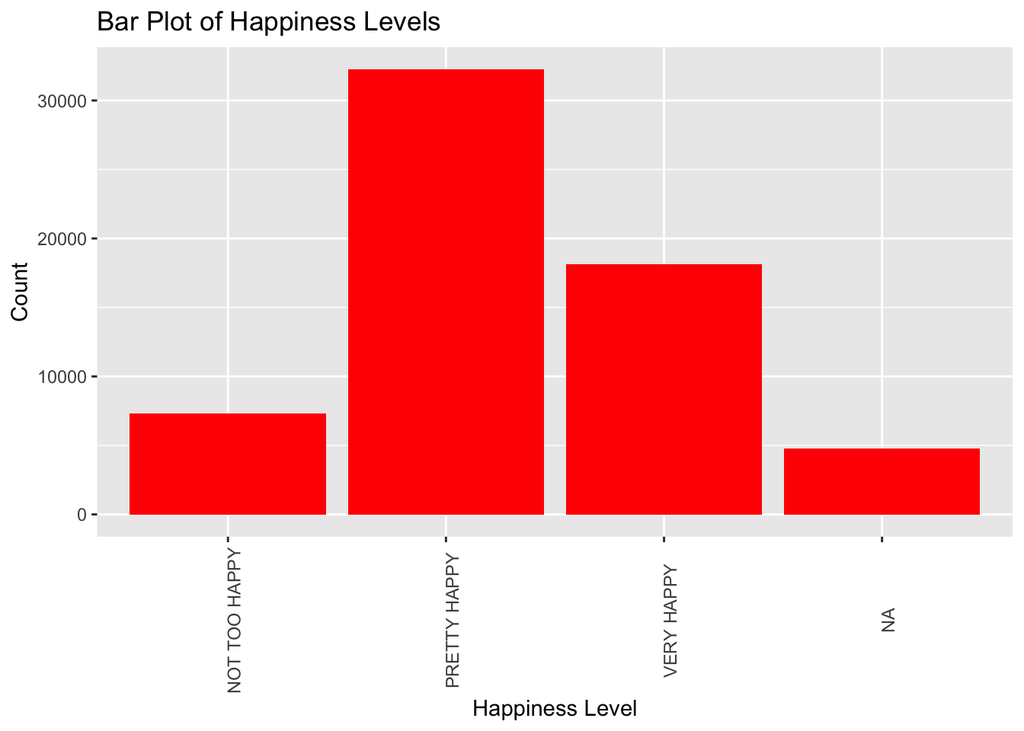

```r
library(ggplot2)
ggplot(data=happydf,aes(happydf$happy))+geom_bar(fill="red",stat="count")+labs(x="Happiness Level",y="Count",title="Bar Plot of Happiness Levels")+theme(axis.text.x = element_text(angle = 90))
```

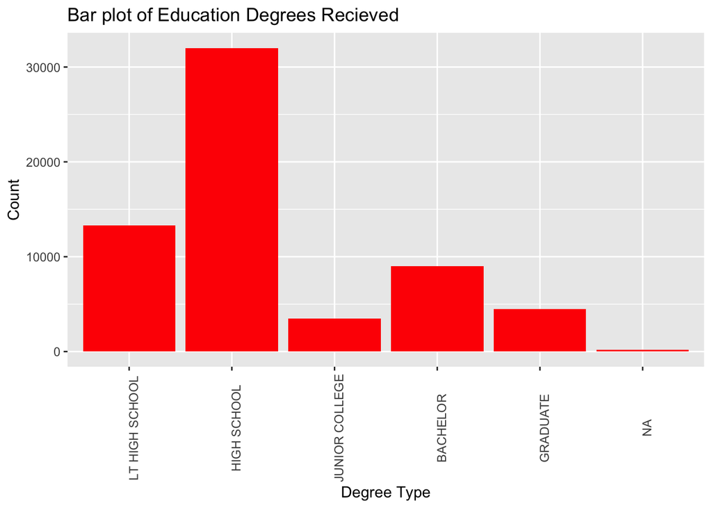

```r
ggplot(data=happydf,aes(x=factor(degree,level=c('NA','LT HIGH SCHOOL','HIGH SCHOOL','JUNIOR COLLEGE','BACHELOR','GRADUATE'))))+geom_bar(fill="red",stat="count")+labs(x="Degree Type",y="Count",title="Bar plot of Education Degrees Recieved")+theme(axis.text.x = element_text(angle = 90))
```

The plot is not uniform more people tend to have smaller high school degrees and less likely to have a higher degree like a graduate degree, so it right skewed.

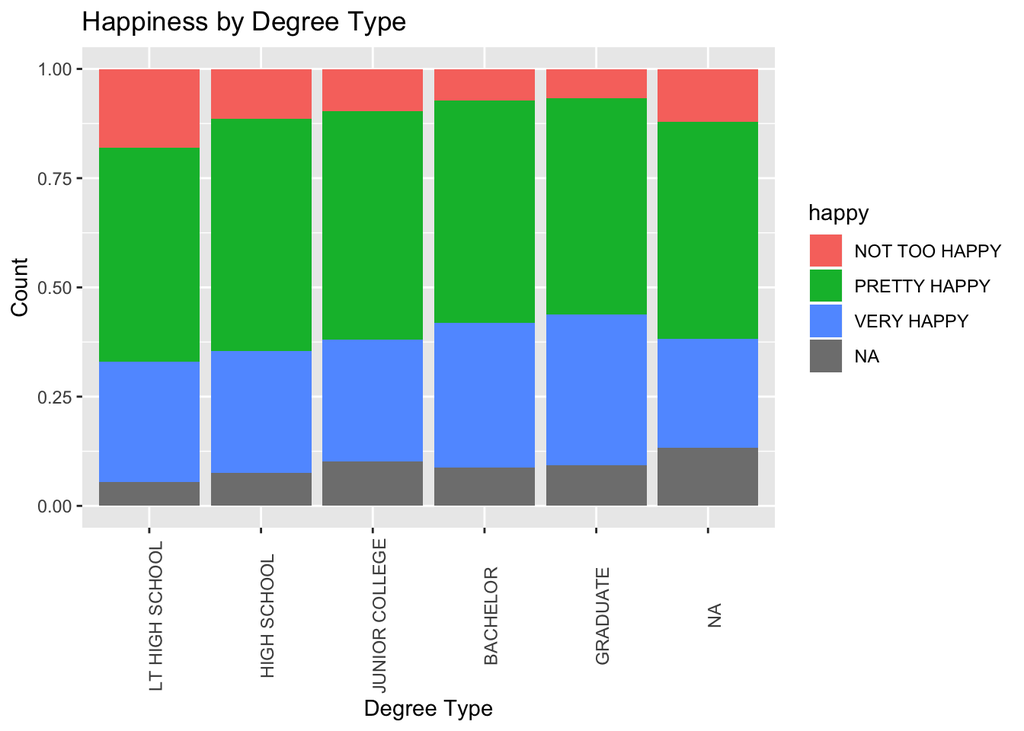

```r
ggplot(happydf,aes(x=factor(degree,level=c('NA','LT HIGH SCHOOL','HIGH SCHOOL','JUNIOR COLLEGE','BACHELOR','GRADUATE')),fill=happy))+geom_bar(position="fill")+theme(axis.text.x = element_text(angle = 90))+labs(x="Degree Type",y="Count",title="Happiness by Degree Type")
```

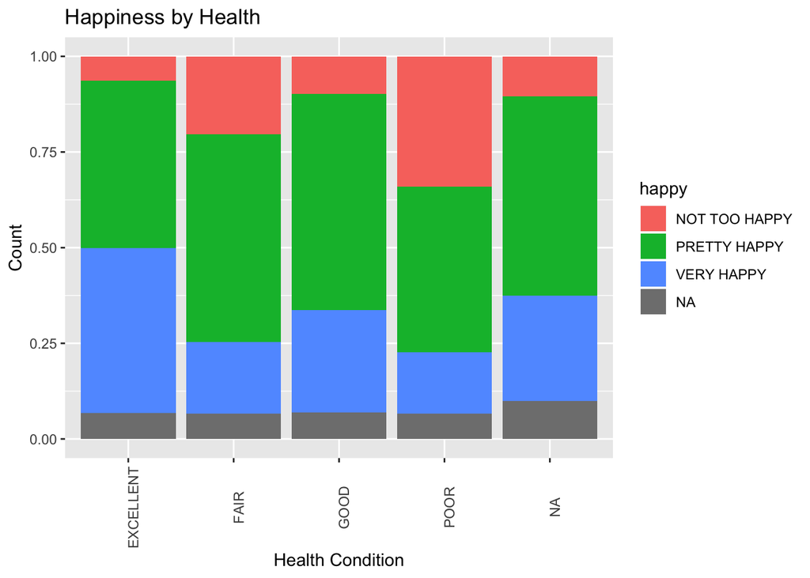

```r
ggplot(happydf,aes(health,fill=happy))+geom_bar(position="fill")+theme(axis.text.x = element_text(angle = 90))+labs(x="Health Condition",y="Count",title="Happiness by Health")
```

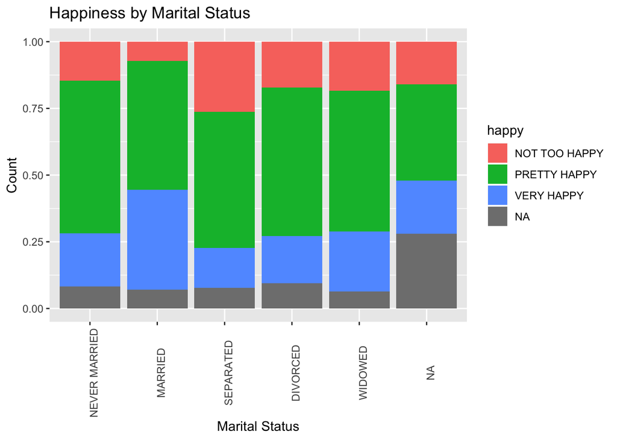

```r
ggplot(happydf,aes(x=factor(marital,level=c('NEVER MARRIED','MARRIED','SEPARATED','DIVORCED','WIDOWED')),fill=happy))+geom_bar(position="fill")+theme(axis.text.x = element_text(angle = 90))+labs(x="Marital Status",y="Count",title="Happiness by Marital Status")
```

3. From the happiness data set we where able to see the response variable of how happy people are with respect to different explanatory variable. we found various relationships of happiness like college degree level, which was positively corelated, with halth it was positively corelated. with being married it was moderately corelated.